# Transit Daily Analysis

## Import Dataset

```r
library(dplyr)
library(stringr)
# set working directory to desktop (where transit_daily.csv is located)
setwd("C:/Users/Kaleo/OneDrive/Desktop")
# read csv into dataframe
raw_transit_data <- read.csv("transit_daily.csv")
```

## Drop Unnecessary Columns and Sort

```r
drop_columns <- c("route_number", "capacity", "early", "on_time", "late", "location_distance", "data_agency", "y_coordinate", "x_coordinate", "data_source", "direction", "trip_number", "stop_id", "vehicle_number", "train", "gtfs_stop_id", "pattern_distance", "train_mileage", "gtfs_trip_id", "gtfs_stop_time_id", "stop_time")
# https://www.listendata.com/2015/06/r-keep-drop-columns-from-data-frame.html
transit_data <- raw_transit_data[,!(names(raw_transit_data) %in% drop_columns)]
# sort data by date, trip number, and arrival time
transit_data <- transit_data[order(transit_data$service_date, transit_data$trip_id, transit_data$arrival_time, decreasing=FALSE),]
```

## Variable Definitions:

- **lift** -number of times the vehicle lift was used at the stop
- **ons** -the raw APC count of the number of persons boarding the vehicle
- **offs** -the raw APC count of the number of persons leaving the vehicle
- **estimated_load** -Estimated load when leaving the stop from adjusted APC data. This field will be zero if the APC counts were identified as invalid.
- **door** -The number of times the door was opened at the stop.
- **maximum_speed** -Maximum speed in mph since prior stop record. This value is not reliable in areas where GPS signals are reflected, such as areas with tall building and on some bridges. Such reflected signals create multi-path interference that may cause GPS units to generate false coordinates.
- **service_key** -A designation for the types of service provided on different calendar dates. Common Service Keys, such as ‘W’, ‘S’, and ‘U’, specify regular Weekday, Saturday, and Sunday service.
- **dwell** -The number of seconds the door is open.
- **train_mileage** -Cumulative distance in miles from the start of the train’s recorded service. This distance is the sum of the tenth mile odometer ticks in the current and all prior stop records generated during the service day for the block.
- **schedule_status** - [see below]

[output not shown]

## Convert Deviance into Seconds

```r
dev_to_s <- function(x){
  total <- 0
  x2 <- as.integer(unlist(strsplit(str_replace_all(gsub('\\+', ':', gsub('days', '', x)), " ", ''), ":")))
  if(length(x2) < 4){
    total <- (x2[1]*3600)+(x2[2]*60)+x2[3]
  }
  else{
    total <- (x2[1]*86400)+(x2[2]*3600)+(x2[3]*60) + x2[4]
  }
  return (total)
}

transit_data$deviance <- unlist(lapply(transit_data$deviance, dev_to_s), recursive = FALSE)
```

## Create Extra Variables

- **seconds_stopped** -Seconds stopped at bus stop calculated by difference in departure and arrival time
- **next_dev** -lag variable showing how many seconds the bus deviated from the scheduled arrival time at the next stop

```r
transit_data$seconds_stopped <- with(transit_data, departure_time - arrival_time)
# Copy arrival time of next row into new column
transit_data$next_dev <- c(tail(transit_data$deviance, -1), NA)
# Remove first row (no data in it)
transit_data <- tail(transit_data, -1)
# https://stackoverflow.com/questions/41069925/dropping-removing-last-first-row-in-each-group-r/50124706
# drop last row of each group since the last stop won't have proper 'next' arrival time
transit_data <- transit_data %>% group_by(trip_id) %>% slice(1:(n()-1)) %>% ungroup()
```

## Quick View of the Data

```r
summary(transit_data)
```

```
      id            service_date        arrival_time   departure_time       door
 Length:517627      Length:517627      Min.   :14485   Min.   :14485   Min.   :0.0000
 Class :character   Class :character   1st Qu.:35820   1st Qu.:35842   1st Qu.:0.0000
 Mode  :character   Mode  :character   Median :52611   Median :52634   Median :0.0000
                                       Mean   :51981   Mean   :51998   Mean   :0.9768
                                       3rd Qu.:66022   3rd Qu.:66040   3rd Qu.:2.0000
                                       Max.   :97492   Max.   :97492   Max.   :2.0000

      lift                ons                offs         estimated_load       dwell
 Min.   :  0.00000   Min.   :  0.0000   Min.   :  0.000   Min.   : 0.000   Min.   :   0.000
 1st Qu.:  0.00000   1st Qu.:  0.0000   1st Qu.:  0.000   1st Qu.: 0.000   1st Qu.:   0.000
 Median :  0.00000   Median :  0.0000   Median :  0.000   Median : 8.000   Median :   0.000
 Mean   :  0.01345   Mean   :  0.5934   Mean   :  0.584   Mean   : 9.474   Mean   :   8.319
 3rd Qu.:  0.00000   3rd Qu.:  1.0000   3rd Qu.:  1.000   3rd Qu.:15.000   3rd Qu.:   9.000
 Max.   :164.00000   Max.   :214.0000   Max.   :204.000   Max.   :67.000   Max.   :5159.000

 maximum_speed   schedule_status service_key           trip_id           deviance
 Min.   : 0.00   Min.   :2.000   Length:517627      Min.   :7171348   Min.   :-2204.0
 1st Qu.:22.00   1st Qu.:2.000   Class :character   1st Qu.:7171709   1st Qu.:  -21.0
 Median :27.00   Median :2.000   Mode  :character   Median :7189591   Median :   44.0
 Mean   :26.35   Mean   :2.288                      Mean   :7195538   Mean   :   83.2
 3rd Qu.:31.00   3rd Qu.:2.000                      3rd Qu.:7225511   3rd Qu.:  144.0
 Max.   :77.00   Max.   :6.000                      Max.   :7225773   Max.   :12905.0
                                                                      NA's   :5272
 seconds_stopped      next_dev
 Min.   :   0.00   Min.   :-2204.00
 1st Qu.:   0.00   1st Qu.:  -21.00
 Median :   0.00   Median :   44.00
 Mean   :  16.69   Mean   :   83.82
 3rd Qu.:  18.00   3rd Qu.:  144.00
 Max.   :6491.00   Max.   :13813.00
                   NA's   :5241
```

```r
head(transit_data)
```

| id | service_date | arrival_time | departure_time | door | lift | ons | offs | estimated_load | dwell | maximum_speed | schedule_status | service_key | trip_id | deviance | seconds_stopped | next_dev |
| --- | --- | --- | --- | --- | --- | --- | --- | --- | --- | --- | --- | --- | --- | --- | --- | --- |
| 3913015 | 3/11/17 | 19813 | 19813 | 2 | 0 | 0 | 0 | 0 | 0 | 0 | 5 | S | 7171348 | 73 | 0 | 33 |
| 3913009 | 3/11/17 | 19947 | 19994 | 2 | 0 | 0 | 0 | 0 | 1 | 26 | 2 | S | 7171348 | 33 | 47 | 17 |
| 3913046 | 3/11/17 | 20092 | 20113 | 2 | 0 | 1 | 0 | 1 | 8 | 23 | 2 | S | 7171348 | 17 | 21 | 9 |
| 3913063 | 3/11/17 | 20179 | 20229 | 2 | 0 | 2 | 0 | 3 | 33 | 16 | 4 | S | 7171348 | 9 | 50 | 19 |
| 3913029 | 3/11/17 | 20316 | 20316 | 0 | 0 | 0 | 0 | 3 | 0 | 18 | 2 | S | 7171348 | 19 | 0 | 2 |
| 3912992 | 3/11/17 | 20366 | 20376 | 2 | 0 | 0 | 0 | 3 | 4 | 20 | 2 | S | 7171348 | 2 | 10 | 36 |

## Histograms of Data

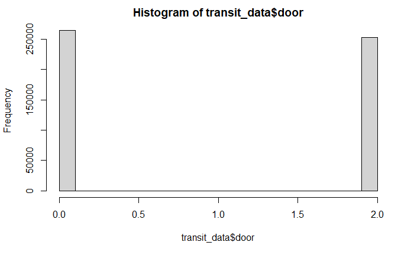

```r
hist(transit_data$door)
```

```r
table(transit_data$door)
```

```
     0      1      2
264814      1 252812
```

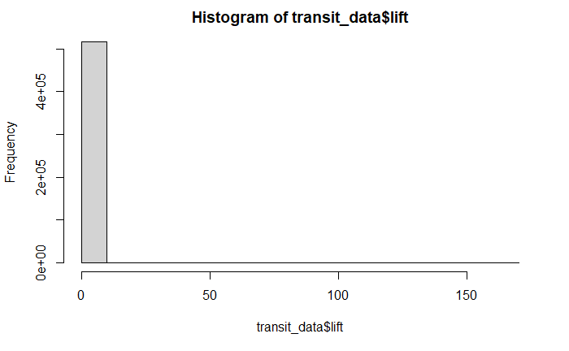

```r
hist(transit_data$lift)
```

```r
table(transit_data$lift)
```

```
     0      1      2      3      4      5      6      7      8      9     10     11     12     13
513713   3171    307     97     79     49     44     33     18     16     19     13     16     11
    14     15     16     17     18     19     20     21     22     25     28    164
     7      2      5      9      2      6      4      1      1      2      1      1
```

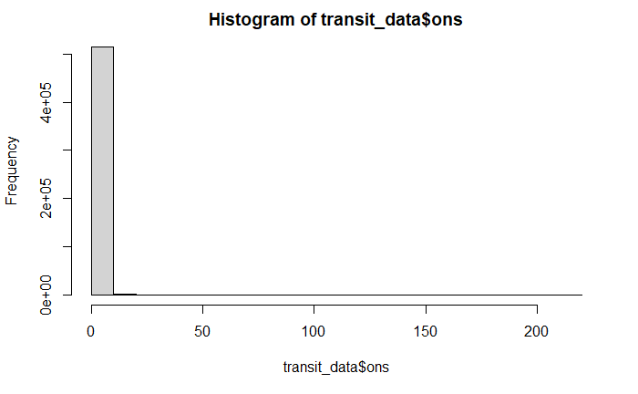

```r
hist(transit_data$ons)
```

```r
table(transit_data$ons)
```

```
     0      1      2      3      4      5      6      7      8      9     10     11     12     13
383930  69856  28950  13744   7530   4250   2816   1810   1287    881    608    426    335    261
    14     15     16     17     18     19     20     21     22     23     24     25     26     27
   201    139    107     64     74     44     33     18     17     21     23     17     15     12
    28     29     30     31     32     33     34     35     36     37     38     39     40     41
     8      8      7      8     11      6      3      6      3      7      5      5      3      4
    42     43     44     45     46     47     48     49     50     51     52     53     54     55
     5      3      1      5      1      3      6      3      1      3      1      1      2      3
    56     57     58     59     60     61     62     63     66     67     68     71     73     75
     2      1      4      1      1      2      1      1      2      2      2      1      1      3
    76     80     81     88     99    101    102    105    214
     1      3      1      1      1      2      1      1      1
```

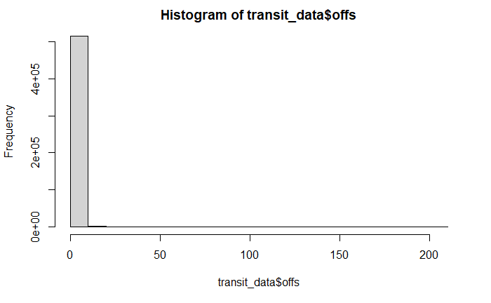

```r
hist(transit_data$offs)
```

```r
table(transit_data$offs)
```

```
     0      1      2      3      4      5      6      7      8      9     10     11     12     13
382420  68310  31888  15219   7925   4311   2526   1552   1019    677    404    289    212    150
    14     15     16     17     18     19     20     21     22     23     24     25     26     27
   108     76     65     48     37     33     34     22     26     17     13     11     11     10
    28     29     30     31     32     33     34     35     36     37     38     39     40     41
     9     10      8      9     12     11      8      9      4      5      4      9      3      4
    42     43     44     45     46     47     48     49     50     51     52     53     54     55
     9      5      4      2      7      3      1      1      2      6      6      2      4      5
    56     57     58     59     60     61     63     64     65     67     68     69     70     71
     1      2      1      1      3      2      2      4      3      1      1      3      1      1
    72     75     76     77     79     82     84     85     87     91     93     95    104    109
     4      3      3      1      1      1      2      1      1      1      1      1      1      1
   111    114    120    204
     1      1      1      1
```

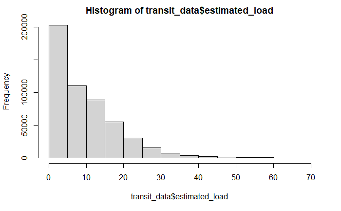

```r
hist(transit_data$estimated_load)
```

```r
table(transit_data$estimated_load)
```

```
     0      1      2      3      4      5      6      7      8      9     10     11     12     13
131833  10146  11545  13998  16693  19071  21305  22462  22320  22183  22098  21215  18718  17432
    14     15     16     17     18     19     20     21     22     23     24     25     26     27
 16324  14937  13664  11932  10929   9960   8615   7634   6741   6129   5190   4632   4001   3483
    28     29     30     31     32     33     34     35     36     37     38     39     40     41
  2920   2615   2106   1860   1579   1400   1211   1067    963    908    748    674    588    555
    42     43     44     45     46     47     48     49     50     51     52     53     54     55
   433    406    353    258    245    197    197    171    141    128    130    105     94     86
    56     57     58     59     60     61     62     63     64     65     66     67
    63     59     46     46     26     18     15     12      6      4      2      2
```

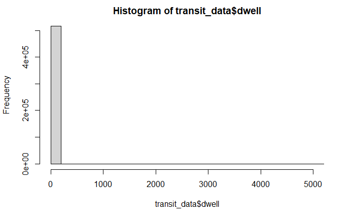

```r
hist(transit_data$dwell)
```

```r
table(transit_data$dwell)
```

```
     0      1      2      3      4      5      6      7      8      9     10     11     12     13
271913    283   1594   6799  16768  23765  23436  21083  18195  15202  12966  10902   9191   7904
    14     15     16     17     18     19     20     21     22     23     24     25     26     27
  6900   5926   5137   4565   3934   3594   3199   2850   2488   2303   2077   1893   1686   1609
    28     29     30     31     32     33     34     35     36     37     38     39     40     41
  1404   1299   1256   1121   1105   1039    935    949    907    794    777    635    666    597
    42     43     44     45     46     47     48     49     50     51     52     53     54     55
   586    559    561    486    472    457    432    385    404    399    346    339    339    343
    56     57     58     59     60     61     62     63     64     65     66     67     68     69
   306    301    254    242    237    245    217    194    187    199    147    208    163    168
    70     71     72     73     74     75     76     77     78     79     80     81     82     83
   164    140    159    128    126    160    120    162    146    114    135    108    110     97
    84     85     86     87     88     89     90     91     92     93     94     95     96     97
   107    118    111    103     93     87    105     81     97     66     80     72     85     93
    98     99    100    101    102    103    104    105    106    107    108    109    110    111
```

[output cut: 97 more lines]

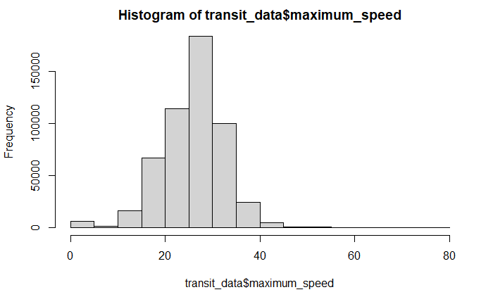

```r
hist(transit_data$maximum_speed)
```

```r
table(transit_data$maximum_speed)
```

```
    0     1     2     3     4     5     6     7     8     9    10    11    12    13    14    15
 5258    36    47    50    97    96   137   168   190   350   434   726  1227  3378  4280  6634
   16    17    18    19    20    21    22    23    24    25    26    27    28    29    30    31
 9105 16724 13069 13511 14211 22955 18469 21085 23902 27634 44706 32415 32715 31578 42837 26757
   32    33    34    35    36    37    38    39    40    41    42    43    44    45    46    47
23201 18752 20884 10747  7987  5712  5337  2777  2134  1463   961  1034   544   371   227   193
   48    49    50    51    52    53    54    55    56    57    58    59    60    61    62    63
  127    93    58    72    25    23    21    20    12     3     4     4     8     7     2     8
   64    65    66    67    68    69    70    71    72    76    77
    8     6     1     2     3     3     2     1     7     1     1
```

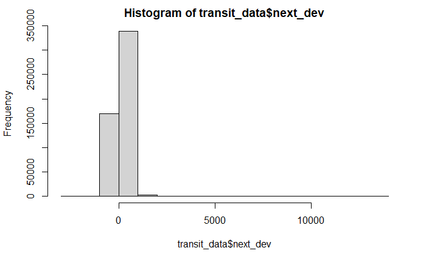

```r
hist(transit_data$next_dev)
```

```r
table(transit_data$next_dev)
```

```
-2204 -2018 -2005 -1924 -1911 -1844 -1841 -1818 -1815 -1797 -1795 -1790 -1775 -1773 -1755 -1754
    1     1     1     1     1     1     1     1     2     2     1     1     1     1     1     1
-1632 -1612 -1587 -1574 -1573 -1570 -1558 -1553 -1551 -1538 -1496 -1482 -1474 -1468 -1460 -1454
    1     1     1     1     1     1     1     1     1     1     1     1     1     1     1     1
-1446 -1439 -1421 -1408 -1389 -1387 -1371 -1368 -1361 -1342 -1341 -1309 -1306 -1297 -1289 -1284
    1     1     2     1     1     1     1     1     1     1     1     1     1     2     1     1
-1283 -1251 -1221 -1204 -1202 -1191 -1183 -1172 -1132 -1130 -1087 -1073 -1065 -1057  -989  -981
    1     1     1     1     1     1     1     1     1     1     1     1     1     1     1     1
 -934  -915  -753  -671  -670  -643  -612  -594  -570  -556  -553  -538  -536  -534  -526  -523
    1     1     1     1     1     1     1     1     1     1     1     1     1     1     1     1
 -520  -518  -516  -515  -513  -512  -506  -496  -493  -490  -482  -475  -467  -465  -463  -459
    1     1     1     1     1     1     1     2     1     1     1     1     1     1     1     1
 -458  -455  -452  -451  -447  -444  -435  -430  -424  -421  -413  -412  -409  -403  -400  -399
    1     1     2     1     1     1     1     2     1     1     1     1     3     1     1     1
 -397  -395  -392  -391  -390  -389  -387  -386  -385  -383  -382  -381  -380  -379  -376  -375
```

[output cut: 112 more lines]

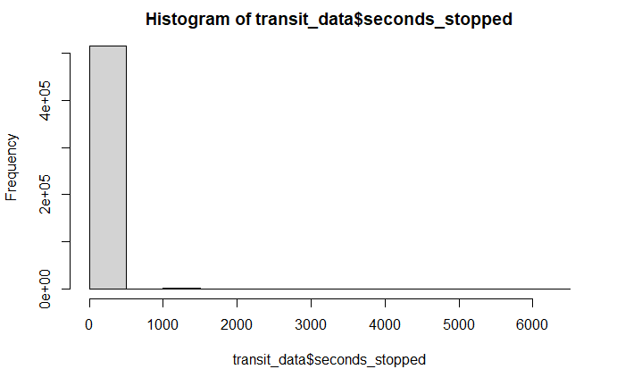

```r
# not necessary to look at deviance since it will be similar to next_dev
hist(transit_data$seconds_stopped)
```

```r
table(transit_data$seconds_stopped)
```

```
     0      1      2      3      4      5      6      7      8      9     10     11     12     13
271845     89     54     65    179    301    630   1383   2812   5255   8983  12302  14434  14984
    14     15     16     17     18     19     20     21     22     23     24     25     26     27
 14006  12460  11072   9595   8838   7574   6849   6003   5467   4897   4519   4168   3917   3534
    28     29     30     31     32     33     34     35     36     37     38     39     40     41
  3263   2918   2742   2450   2325   2126   2123   2049   1863   2040   1919   1746   1664   1514
    42     43     44     45     46     47     48     49     50     51     52     53     54     55
  1405   1377   1355   1335   1295   1222   1247   1142   1224   1215   1160   1241   1417   1365
    56     57     58     59     60     61     62     63     64     65     66     67     68     69
  1470   1458   1509   1456   1371   1222   1066   1035    917    818    737    733    635    612
    70     71     72     73     74     75     76     77     78     79     80     81     82     83
   548    525    507    430    461    414    385    364    349    331    336    313    308    317
    84     85     86     87     88     89     90     91     92     93     94     95     96     97
   291    285    277    256    256    238    229    236    225    199    211    187    215    218
    98     99    100    101    102    103    104    105    106    107    108    109    110    111
```

[output cut: 130 more lines]

## Trimmed Histograms (ignoring outliers for better view of where to bin)

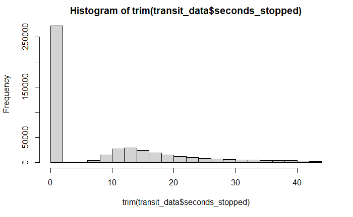

```r
# https://stackoverflow.com/questions/53833773/how-to-make-a-trimmed-histogram-in-r
trim <- function(x){
  x[(x > mean(x)-1.5*IQR(x)) & (x < mean(x)+1.5*IQR(x))]
}
hist(trim(transit_data$seconds_stopped))
```

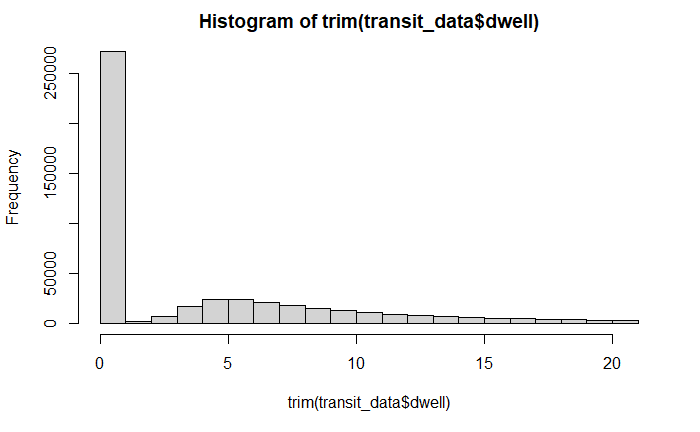

```r
hist(trim(transit_data$dwell))
```

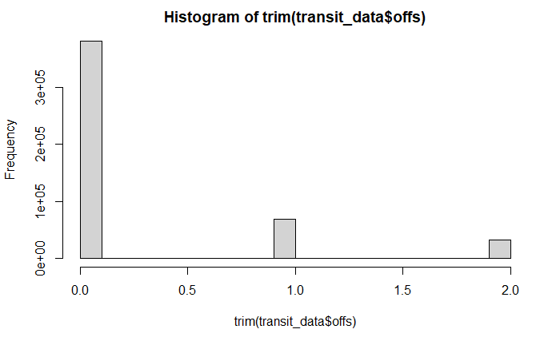

```r
hist(trim(transit_data$offs))
```

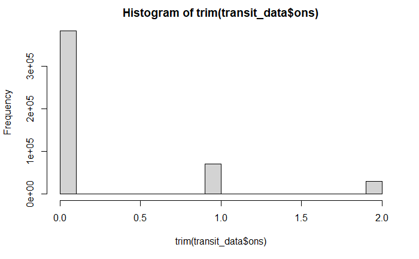

```r
hist(trim(transit_data$ons))
```

## Binning Information

The data was discritized by binning into the following below

[output not shown]

## Binning

```r
# bin 'door'
transit_data$door[transit_data$door > 0] <- 1
# bin 'lift'
transit_data$lift[transit_data$lift > 0] <- 1
# bin 'ons'
temp <- transit_data$ons
transit_data$ons[temp > 0 & temp <=5] <- 1
transit_data$ons[temp > 5] <- 2
# bin 'offs'
temp <- transit_data$offs
transit_data$offs[temp > 0 & temp <=5] <- 1
transit_data$offs[temp > 5] <- 2
# bin 'estimated_load'
temp <- transit_data$estimated_load
transit_data$estimated_load[temp > 0 & temp <=5] <- 1
transit_data$estimated_load[temp > 5 & temp <=10] <- 2
transit_data$estimated_load[temp > 10 & temp <=15] <- 3
transit_data$estimated_load[temp > 15] <- 4
# bin 'dwell'
temp <- transit_data$dwell
transit_data$dwell[temp > 0 & temp <=15] <- 1
transit_data$dwell[temp > 15] <- 2
# bin 'maximum_speed'
temp <- transit_data$maximum_speed
transit_data$maximum_speed[temp <= 15] <- 0
transit_data$maximum_speed[temp > 15 & temp <=20] <- 1
transit_data$maximum_speed[temp > 20 & temp <=25] <- 2
transit_data$maximum_speed[temp > 25 & temp <=30] <- 3
transit_data$maximum_speed[temp > 30 & temp <=35] <- 4
transit_data$maximum_speed[temp > 35] <- 5
# bin 'seconds_stopped'
temp <- transit_data$seconds_stopped
transit_data$seconds_stopped[temp > 0 & temp <=15] <- 1
transit_data$seconds_stopped[temp > 15 & temp <=30] <- 2
transit_data$seconds_stopped[temp > 30 & temp <=60] <- 3
transit_data$seconds_stopped[temp > 60 & temp <=120] <- 4
transit_data$seconds_stopped[temp > 120] <- 5
# bin 'deviance'
temp <- transit_data$deviance
transit_data$deviance[temp <=-300] <- 0
transit_data$deviance[temp > -300 & temp <=-240] <- 1
transit_data$deviance[temp > -240 & temp <=-180] <- 2
transit_data$deviance[temp > -180 & temp <=-120] <- 3
transit_data$deviance[temp > -120 & temp <=-60] <- 4
transit_data$deviance[temp > -60 & temp <=0] <- 5
transit_data$deviance[temp > 0 & temp <=60] <- 6
transit_data$deviance[temp > 60 & temp <=120] <- 7
transit_data$deviance[temp > 120 & temp <=180] <- 8
transit_data$deviance[temp > 180 & temp <=240] <- 9
transit_data$deviance[temp > 240 & temp <=300] <- 10
transit_data$deviance[temp > 300 & temp <=360] <- 11
transit_data$deviance[temp > 360 & temp <=420] <- 12
transit_data$deviance[temp > 420 & temp <=480] <- 13
transit_data$deviance[temp > 480] <- 14
# bin 'next_dev'
temp <- transit_data$next_dev
transit_data$next_dev[temp <=-300] <- 0
transit_data$next_dev[temp > -300 & temp <=-240] <- 1
transit_data$next_dev[temp > -240 & temp <=-180] <- 2
transit_data$next_dev[temp > -180 & temp <=-120] <- 3
transit_data$next_dev[temp > -120 & temp <=-60] <- 4
transit_data$next_dev[temp > -60 & temp <=0] <- 5
transit_data$next_dev[temp > 0 & temp <=60] <- 6
transit_data$next_dev[temp > 60 & temp <=120] <- 7
transit_data$next_dev[temp > 120 & temp <=180] <- 8
transit_data$next_dev[temp > 180 & temp <=240] <- 9
transit_data$next_dev[temp > 240 & temp <=300] <- 10
transit_data$next_dev[temp > 300 & temp <=360] <- 11
transit_data$next_dev[temp > 360 & temp <=420] <- 12
transit_data$next_dev[temp > 420 & temp <=480] <- 13
transit_data$next_dev[temp > 480] <- 14
#replace char values in service_key with numeric values
transit_data$service_key[transit_data$service_key == 'e'] <- 0
transit_data$service_key[transit_data$service_key == 'S'] <- 1
transit_data$service_key[transit_data$service_key == 'U'] <- 2
transit_data$service_key[transit_data$service_key == 'W'] <- 3
```

## Final Column Drop

```r
drop_columns <- c("service_date")
transit_data <- na.omit(transit_data)[,!(names(transit_data) %in% drop_columns)]
```

## Export Data to CSV and TXT for OCCAM

```r
write.csv(transit_data, "modified_transit_data.csv", row.names = FALSE)
# Create formatted OCCAM Input File
cat(":nominal", "id, 517627, 0, Id", "arrival_time, 76382,0, At", "departure_time, 76467, 0, Dt", "door, 2, 1, Do", "lift, 2, 1, L", "ons, 3, 1, On", "offs, 3, 1, Off", "estimated_load, 5, 1, El", "dwell, 3, 1, Dw", "maximum_speed, 6, 1, Ms", "schedule_status, 6, 1, ScS", "service_key, 4, 1, Sk", "trip_id, 1245, 0, Tid", "deviance, 15, 1, Dev", "seconds_stopped, 6, 1, Ss", "next_dev, 15, 2, Nd", ":no-frequency", ":data", file = "transit_data_input.txt", sep = "\n")
write.table(transit_data, file = 'transit_data_input.txt', append=TRUE, quote=FALSE, sep = "\t", row.names = FALSE, col.names = FALSE)
```